# Lab: Bioconductor tools for mass spectrometry and proteomics

Laurent Gatto

11 July 2018

**Abstract** In this workflow, we will use R/Bioconductor packages to explore, process, visualise and understand mass spectrometry-based proteomics data, starting with raw data, and proceeding with identification and quantitation data, discussing some of their peculiarities compared to sequencing data along the way. The workflow is aimed at a beginner to intermediate level, such as, for example, seasoned R users who want to get started with mass spectrometry and proteomics, or proteomics practitioners who want to familiarise themselves with R and Bioconductor infrastructure.

> This material available under a [**creative common CC-BY**](http://creativecommons.org/licenses/by/4.0/) license. You are free to **share** (copy and redistribute the material in any medium or format) and **adapt** (remix, transform, and build upon the material) for any purpose, even commercially.

# 1 Introduction

Before we start:

> If you identify typos, if there are parts that you would like to see expended or clarified, please let me know by telling me directly (during workshops), opening a [github issue](https://github.com/lgatto/bioc-ms-prot/issues) or by emailing me directly. Please do also briefly specify your background/familiarity with mass spectrometry and/or proteomics (beginner, intermediate or expert) so that I can update accordingly.

In recent years, there we have seen an increase in the number of packages to analyse mass spectrometry and proteomics data for R and Bioconductor, as well as an increase in total number of downloads. See vignette [Proteomics packages in Bioconductor](https://lgatto.github.io/RforProteomics/articles/biocprot.html) for more details and code underlying these figures.

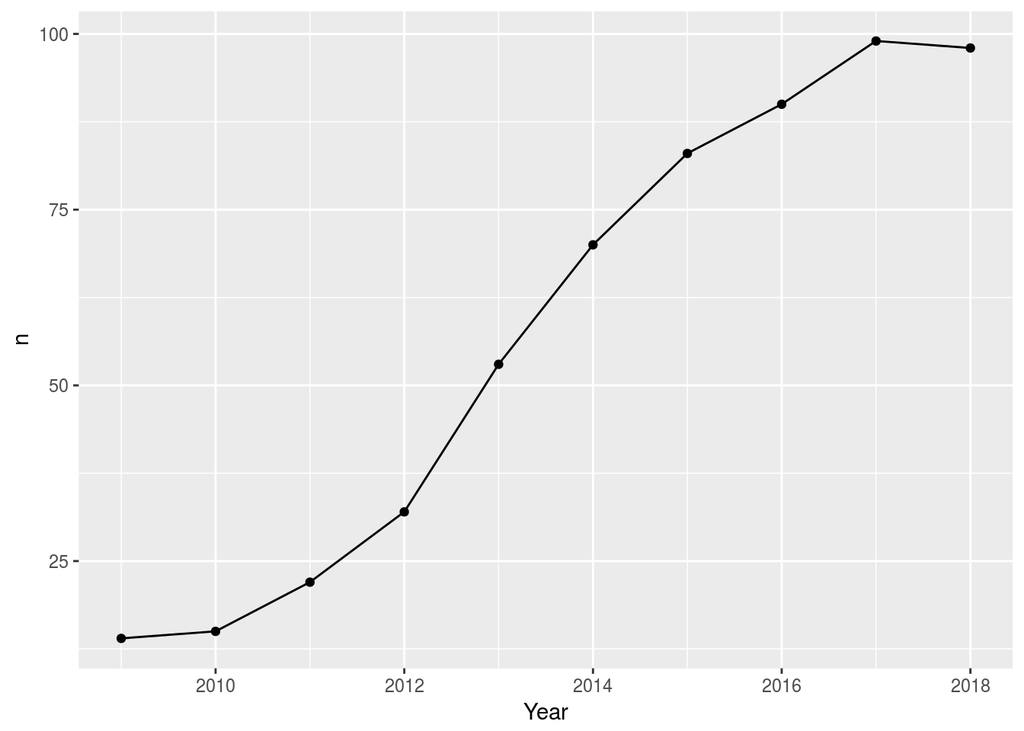

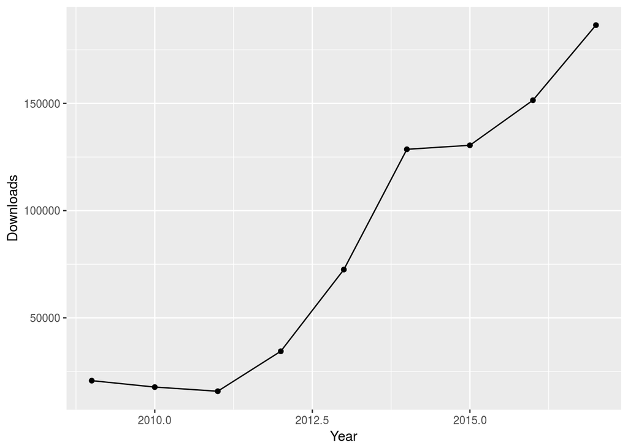

It is also good to highlight that several of these package have become a group efforts, supported by several developers in the community. This [post](https://lgatto.github.io/msnbase-contribs/) illustrates the various contributions to *MSnbase*. *mzR* has benefited by a similar wide range of successful contributions. Both packages, and in particular *mzR*, are used by many others, and will be described in some detail in this workflow.

This workflow illustrates R / Bioconductor infrastructure for proteomics. Topics covered focus on support for open community-driven formats for raw data and identification results, packages for peptide-spectrum matching, data processing and analysis:

- Exploring available infrastructure
- Mass spectrometry data
- Getting data from proteomics repositories
- Handling raw MS data
- Handling identification data
- MS/MS database search
- Analysing search results
- High-level data interface
- Quantitative proteomics
- Importing third-party quantitation data
- Data processing and analysis
- Statistical analysis
- Machine learning
- Annotation
- Other relevant packages/pipelines

Links to other packages and references are also documented. In particular, the vignettes included in the *RforProteomics* package also contains relevant material.